# Flights Data Exploration

## by (Hazem Fathy)

## Preliminary Wrangling

This document explores flights in the United States, including carriers, arrival and departure delays, and reasons for delays, from 2006 to 2008.

### **What is the structure of your dataset?**

> There are 16984354 Flights with 29 features. Most variables are numeric in nature, but the variables (UniqueCarrier,Origin,Dest,CancellationCode) are categoric

### **What is/are the main feature(s) of interest in your dataset?**

> I'm most interested in figuring out what features are best for predicting that:are there certain destination or arrival cities that are home to more delays or cancellations

### **What features in the dataset do you think will help support your investigation into your feature(s) of interest?**

> I think number of cancelled flights or delayed flights thow origins and Destinations could give us good Insights and also with delay reasons and Cancellation reasons give us if origins and Destinations have responsible for them

## are there certain destination or arrival cities that are home to more delays or cancellations?

## Univariate Exploration

I'll start by looking at the distribution of the main variables of interest: Origin,Dest

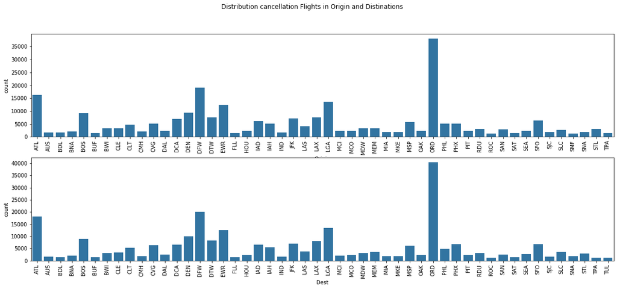

```python
flights_Cancelled_top50Origin=flights_Cancelled_top50Origin.sort_values('Origin') # sort to make Comparison between Dest and Origin better
flights_Cancelled_top50Dest=flights_Cancelled_top50Dest.sort_values('Dest')

fig, ax = plt.subplots(nrows=2, figsize = [20,8])
default_color = sb.color_palette()[0]
sb.countplot(data =flights_Cancelled_top50Origin, x ='Origin', color = default_color,ax=ax[0])

sb.countplot(data =flights_Cancelled_top50Dest, x = 'Dest', color = default_color,ax= ax[1])

for ax in fig.axes:
    plt.sca(ax)
    plt.xticks(rotation=90)


plt.suptitle("Distribution cancellation Flights in Origin and Distinations ")
plt.show()
```

ORD and DFW have biggst number of Cancellation as both Origin and Destination

### are there any ather observations

almost all destinations and origins have same order of number of delayed flights ( ORD have biggst number of cancellation both as origins and destinations)

### **What is the most frequent reason to cancel flights**

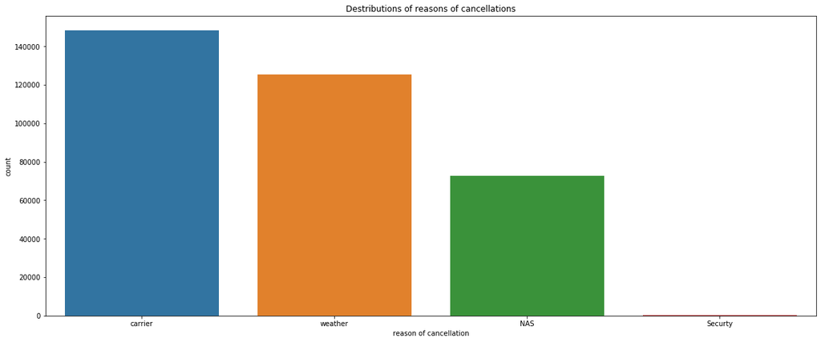

```python
fig, ax = plt.subplots(figsize = [20,8])
cc_mapping_kays=["A","B","C","D"]
cc_mapping_values=["carrier","weather","NAS","Securty"]

ax=sb.countplot(data =flights_Cancelled, x ='CancellationCode',order=cc_mapping_kays)
ax.set_xticklabels(cc_mapping_values)
plt.xlabel('reason of cancellation')
plt.title('Destributions of reasons of cancellations')
```

Most of the reasons for the cancellation are due to Carrier which means Administrative or commercial reasons . Securty reasions Relatively very small which means there is great attention to Sceurty

### Bivariate Exploration

To start off with, I want to look at the pairwise correlations present between Origin and Cacellation code.

### **What are the proportion of causes of cancellation across Origins ?**

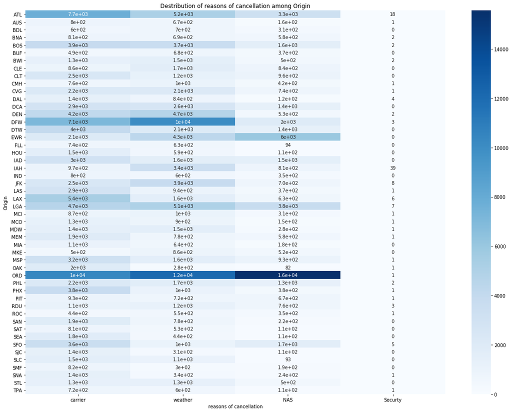

```python
fig, ax = plt.subplots(figsize = [20,15])
xticks =["carrier","weather","NAS","Securty"]
ax=sb.heatmap(Cancel_count,cmap="Blues",annot = True,xticklabels=xticks);
plt.xlabel('reasons of cancellation')
plt.title('Destribution of reasons of cancellation among Origin')
```

### Bivariate Exploration

I want to look at the pairwise correlations present between Dest and Cacellation code.

### **What are the percentages of causes of cancellation across Destinations ?**

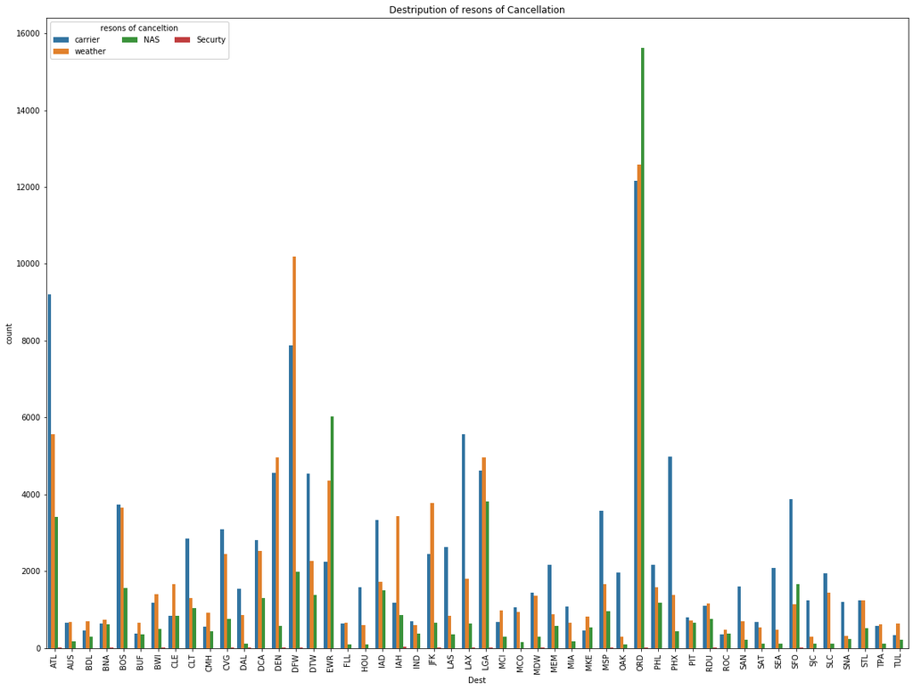

```python
fig, ax = plt.subplots(figsize = [20,15])
cc_mapping_kays=["A","B","C","D"]
cc_mapping_values=["carrier","weather","NAS","Securty"]  # to replace coulmns headeres with what headers mean
ax = sb.countplot(data = flights_Cancelled_top50Dest, x = 'Dest',hue='CancellationCode',hue_order=cc_mapping_kays)
legend_labels, _= ax.get_legend_handles_labels()
ax.legend(legend_labels,cc_mapping_values, title='resons of canceltion',loc = 2, ncol = 3, framealpha = 1)

plt.xticks(rotation=90)
plt.title('Destripution of resons of Cancellation')
```

there is no specific pattern for distribution of reasons of cancellation throw Destinations

## Multivariate Exploration

### The main thing I want to explore in this part of the analysis is the relation between delay time and delay reasons throw differnt Destinations

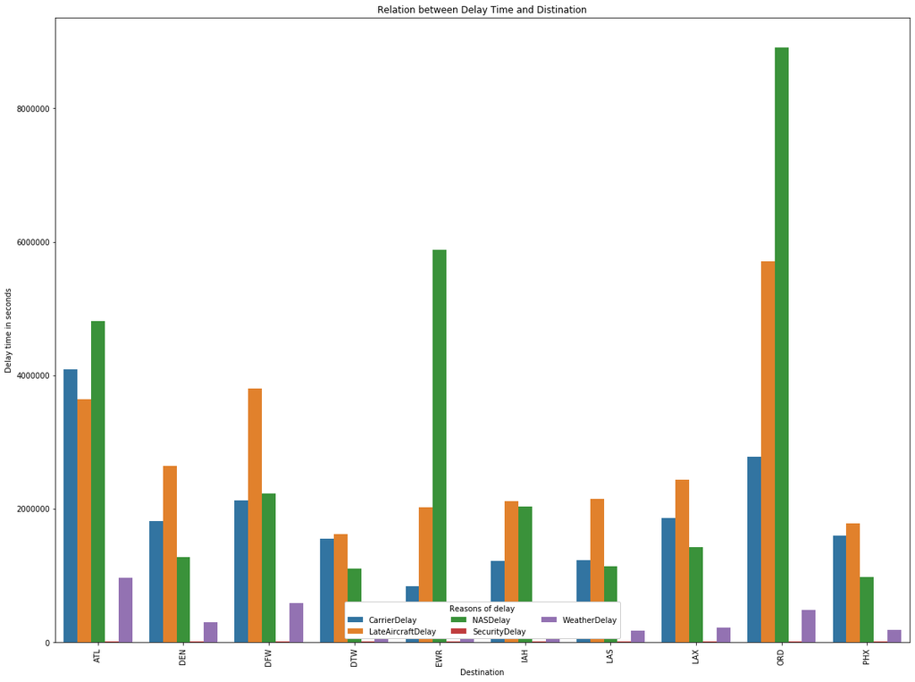

```python
fig, ax = plt.subplots(figsize = [20,15])
ax = sb.barplot(data = Delay_sum, x = 'Dest', y = 'Delay_time', hue = 'reson of delay')
ax.legend(loc = 8, ncol = 3, framealpha = 1, title = 'Reasons of delay')
plt.xticks(rotation=90)
plt.ylabel('Delay time in seconds')
plt.xlabel('Destination')
plt.title("Relation between Delay Time and Distination")
```

there is tidiness issue 5 coulmns(CarrierDelay','WeatherDelay','NASDelay','SecurityDelay','LateAircraftDelay') and two vairabls

the most greatest amounts of time of delay because of Carrier delay,lateAircraft delay and Nas Delay .Their size order varies across Destinations .Securty is in best condition in all DestinationsوIt is rarely a reason for delays